# **Topic 8 - Functions in R**

Esam Mahdi

2026-05-04

# Introduction to Functions

- **Encapsulate** reusable code into a single named unit
- **Avoid repetition** (Don’t Repeat Yourself)
- **Organize** complex code into manageable pieces
- **Share** your code with others

**What is a Function?**

A **function** is a named block of code that:

- Takes **inputs** (called arguments or parameters)
- Performs a specific **task**
- Returns an **output** (result)

Think of a function like a **recipe**:

- **Ingredients** = arguments you provide
- **Instructions** = code inside the function
- **Dish** = the returned result

# Built-in Functions We’ve Used

**R** comes with hundreds of built-in functions:

```r
# Examples of built-in functions
sum(c(1, 2, 3, 4, 5))      # Returns 15
```

```
## [1] 15
```

```r
mean(c(10, 20, 30, 40))     # Returns 25
```

```
## [1] 25
```

```r
sqrt(16)                    # Returns 4
```

```
## [1] 4
```

```r
round(3.14159, digits = 2)  # Returns 3.14
```

```
## [1] 3.14
```

## Getting Help with Functions

Before we start creating our own functions, it’s important to know how to get help with existing functions. **R** has a built-in help system that provides documentation for all functions in base **R** and installed packages.

** The `?` Operator and `help()` Function**

You can access documentation for any function using either:

- `?function_name`
- `help(function_name)`

**Example: Understanding `rnorm()`**

Let’s explore the `rnorm()` function, which generates random numbers from a **normal distribution** (bell curve):

```r
# View documentation for rnorm
?rnorm
# or
help(rnorm)
```

**What does `rnorm()` do?**

- Generates random numbers following a normal (Gaussian) distribution
- Commonly used for simulation, statistical modeling, and creating test data

**Arguments of `rnorm()`:**

| Argument | Description | Default |
| --- | --- | --- |
| `n` | Number of random values to generate | Required (no default) |
| `mean` | Mean (center) of the distribution | 0 |
| `sd` | Standard deviation (spread) of the distribution | 1 |

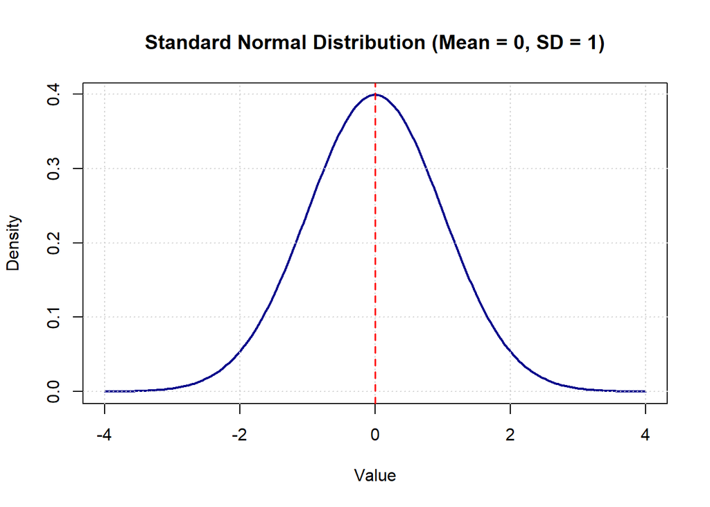

**Examples of using `rnorm()` to generate random numbers:**

```r
# Generate 5 random numbers from a standard normal distribution
# Standard normal has mean = 0 and standard deviation = 1
rnorm(5) # Uses default mean=0 and sd=1

# Generate 5 random numbers from a normal distribution with:
#   mean = 100
#   standard deviation = 4 (variance = 16)
rnorm(5, mean = 100, sd = 4)

# Named arguments allow you to change the order
# This produces the SAME result as the previous example
rnorm(5, sd = 4, mean = 100)

# 💡 TIP: You can use partial argument names (first letter usually works)
rnorm(5, m = 100, s = 4)      # "m" for mean, "s" for sd
rnorm(5, s = 4, m = 100)      # Order still doesn't matter
```

```
# Try these examples yourself
?mean      # Help with the mean() function
?summary   # Help with the summary() function
?read.csv  # Help with reading CSV files
```

**Note:** If you don’t know the exact function name, you can search for functions related to a topic using `??` followed by your topic of interest.

```
# Search for functions related to "correlation"
??correlation

# Search for functions related to "plotting"
??plot
```

# Creating Your Own Functions

## Basic Function Syntax

The basic syntax for creating a function is:

```
function_name <- function(argument1, argument2, ...) {
    # Body of the function (code to execute)
    # ...
    return(result)  # Optional: explicitly return a value
}
```

## Simple Example: A Greeting Function

```r
# Define a function that prints a greeting
say_hello <- function(name) {
    message <- paste("Hello,", name, "!")
    print(message)
}

# Call the function
say_hello("Alice")
```

```
## [1] "Hello, Alice !"
```

```r
say_hello("Bob")
```

```
## [1] "Hello, Bob !"
```

## Functions That Return Values

By default, a function returns the **last evaluated expression:**

```r
# Function that adds 10 to any number
add_ten <- function(number) {
    number + 10  # This is the last expression, so it's returned
}

result <- add_ten(5)
result
```

```
## [1] 15
```

## Using `return()` Explicitly

You can use `return()` to explicitly specify what to return. This is especially useful for:

- Returning early from a function
- Making your code more readable

```r
# Explicit return
add_twenty <- function(number) {
    return(number + 20)  # Explicitly return
    number + 10  # This line never runs!
}

add_twenty(5)
```

```
## [1] 25
```

```r
# Early return example
check_positive <- function(x) {
    if (x <= 0) {
        return("Number is not positive")
    }
    # This only runs if x > 0
    return(sqrt(x))
}

check_positive(-5)
```

```
## [1] "Number is not positive"
```

```r
check_positive(16)
```

```
## [1] 4
```

# Function Arguments

## Required Arguments

Arguments without default values **must** be provided when calling the function:

```r
# Function with two required arguments
multiply <- function(a, b) {
    return(a * b)
}

multiply(4, 5)  # Returns 20
```

```
## [1] 20
```

```r
# multiply(4)   # Error: argument "b" is missing
```

## Default Arguments

You can assign **default** values to arguments. If the user doesn’t provide a value, the default is used:

```r
# Function with default argument
greet <- function(name, greeting = "Hello") {
    return(paste(greeting, name, "!"))
}

greet("Alice")              # Uses default "Hello"
```

```
## [1] "Hello Alice !"
```

```r
greet("Bob", "Hi")          # Overrides default
```

```
## [1] "Hi Bob !"
```

```r
greet("Charlie", "Good morning")
```

```
## [1] "Good morning Charlie !"
```

## Argument Order: Positional vs. Named

You can pass arguments in two ways:

**1. Positional matching** (by order):

```r
# Arguments matched by position
power <- function(base, exponent) {
    return(base ^ exponent)
}

power(2, 3)  # 2^3 = 8
```

```
## [1] 8
```

```r
power(3, 2)  # 3^2 = 9 (different result!)
```

```
## [1] 9
```

**2. Named arguments** (by name, order doesn’t matter):

```r
# Named arguments - order doesn't matter
power(exponent = 3, base = 2)  # Same as power(2, 3)
```

```
## [1] 8
```

```r
power(base = 5, exponent = 2)  # 5^2 = 25
```

```
## [1] 25
```

**3. Mixing positional and named:**

```r
# Mix positional and named
power(2, exponent = 4)  # 2^4 = 16
```

```
## [1] 16
```

```r
# power(base = 2, 4)   # Error: positional after named!
```

**The Ellipsis `...` (Variable Arguments)**

The `...` (called ellipsis or dot-dot-dot) allows a function to accept **any number of arguments**:

```r
# Function that sums any number of arguments
sum_all <- function(...) {
    args <- list(...)  # Convert ... to a list
    total <- 0
    for (value in args) {
        total <- total + value
    }
    return(total)
}

sum_all(1, 2, 3)           # Returns 6
```

```
## [1] 6
```

```r
sum_all(10, 20, 30, 40)    # Returns 100
```

```
## [1] 100
```

```r
sum_all(5)                 # Returns 5
```

```
## [1] 5
```

```r
# Function to find the maximum of any number of arguments
max_of_all <- function(...) {
    args <- list(...)
    current_max <- args[[1]]
    for (value in args) {
        if (value > current_max) {
            current_max <- value
        }
    }
    return(current_max)
}

max_of_all(3, 7, 2, 9, 1)  # Returns 9
```

```
## [1] 9
```

**Passing `...` to Other Functions**

The ellipsis is also useful for passing arguments from one function to another:

```r
# Wrapper function that adds logging to sum()
logged_sum <- function(...) {
    cat("Calculating sum of", length(list(...)), "numbers\n")
    return(sum(...))  # Pass all ... arguments to sum()
}

logged_sum(1, 2, 3, 4, 5)
```

```
## Calculating sum of 5 numbers
```

```
## [1] 15
```

```r
# Wrapper for round() with custom message
smart_round <- function(x, ...) {
    cat("Rounding", x, "\n")
    return(round(x, ...))
}

smart_round(3.14159, digits = 2)
```

```
## Rounding 3.14159
```

```
## [1] 3.14
```

# Scope: Where Variables Live

## Local vs. Global Variables

Variables defined inside a function are local - they don’t exist outside:

```r
my_function <- function(x) {
    local_var <- x * 2  # Local variable
    return(local_var)
}

result <- my_function(5)
print(result)
```

```
## [1] 10
```

```r
# print(local_var)  # Error: object 'local_var' not found
```

## Global Variables

Variables defined outside functions are global and can be accessed inside:

```r
global_message <- "Hello from global!"

show_message <- function() {
    print(global_message)  # Can access global variable
}

show_message()
```

```
## [1] "Hello from global!"
```

## Documenting Functions

Good documentation helps others (and your future self) understand your code:

```
# Well-documented function
calculate_bmi <- function(weight_kg, height_m) {
    """
    Calculate Body Mass Index (BMI)

    Args:
        weight_kg: Weight in kilograms (numeric)
        height_m: Height in meters (numeric)

    Returns:
        BMI value (numeric)

    Formula:
        BMI = weight / (height^2)

    BMI Categories:
        < 18.5: Underweight
        18.5-24.9: Normal weight
        25-29.9: Overweight
        >= 30: Obese
    """
    bmi <- weight_kg / (height_m^2)
    return(round(bmi, 1))
}

# Use the function
calculate_bmi(70, 1.75)
```

# Examples

## Example 1: Temperature Converter

```r
f_to_c <- function(fahrenheit, round_digits = 1) {
    ##########
    # Convert Fahrenheit to Celsius
    # Args:
      # fahrenheit: Temperature in Fahrenheit
      # round_digits: Number of decimal places (default = 1)
    # Returns:
      # Temperature in Celsius
    ##########
    celsius <- (fahrenheit - 32) * 5/9
  return(round(celsius, round_digits))
}

# Convert Celsius to Fahrenheit
c_to_f <- function(celsius, round_digits = 1) {
  ##########
  # Convert Celsius to Fahrenheit
  # Args:
    # celsius: Temperature in Celsius
    # round_digits: Number of decimal places (default = 1)
  # Returns:
  # Temperature in Fahrenheit
  ##########
  fahrenheit <- (celsius * 9/5) + 32
  return(round(fahrenheit, round_digits))
}

# Test the functions
f_to_c(98.6)          # Body temperature: 37.0°C
```

```
## [1] 37
```

```r
c_to_f(37)            # 98.6°F
```

```
## [1] 98.6
```

```r
f_to_c(32)            # Freezing point: 0°C
```

```
## [1] 0
```

```r
c_to_f(0)             # Freezing point: 32°F
```

```
## [1] 32
```

## Example 2: Statistical Calculator

```r
# Calculate several statistics at once
describe_vector <- function(x) {
  ##########
  # Calculate common statistics for a numeric vector
  # Args: x: Numeric vector
  # Returns: List containing mean, median, sd, min, max, and length
  ##########
    result <- list(
        length = length(x),
        mean = mean(x, na.rm = TRUE),
        median = median(x, na.rm = TRUE),
        sd = sd(x, na.rm = TRUE),
        min = min(x, na.rm = TRUE),
        max = max(x, na.rm = TRUE)
    )
    return(result)
}

# Test the function
test_scores <- c(85, 92, 78, 90, 88, 95, 82, 87)
describe_vector(test_scores)
```

```
## $length
## [1] 8
##
## $mean
## [1] 87.125
##
## $median
## [1] 87.5
##
## $sd
## [1] 5.462535
##
## $min
## [1] 78
##
## $max
## [1] 95
```

## Example 3: Grade Calculator

```r
# Convert numeric score to letter grade
letter_grade <- function(score) {
  ##########
    # Convert a numeric score to a letter grade
    # Args: score: Numeric score (0-100)
    # Returns: Character letter grade (A, B, C, D, or F)
  ##########
    if (score >= 90) {
        return("A")
    } else if (score >= 80) {
        return("B")
    } else if (score >= 70) {
        return("C")
    } else if (score >= 60) {
        return("D")
    } else {
        return("F")
    }
}

# Calculate class statistics
class_statistics <- function(grades) {
##########
    # Calculate statistics and grade distribution
    # Args: grades: Numeric vector of grades
    # Returns: List with summary statistics and grade distribution
##########
    # Calculate grade distribution
    distribution <- table(sapply(grades, letter_grade))

    # Calculate numerical statistics
    stats <- list(
        average = mean(grades),
        highest = max(grades),
        lowest = min(grades),
        distribution = distribution
    )

    return(stats)
}

# Test with sample grades
sample_grades <- c(95, 82, 67, 78, 91, 88, 75, 92, 84, 70, 65, 98)
class_statistics(sample_grades)
```

```
## $average
## [1] 82.08333
##
## $highest
## [1] 98
##
## $lowest
## [1] 65
##
## $distribution
##
## A B C D
## 4 3 3 2
```

# Common Mistakes

## Mistake 1: Forgetting to Assign the Function Result

```r
# Wrong: function returns a value but it's not stored
add <- function(a, b) {
    return(a + b)
}
add(5, 3)  # Result printed but not saved
```

```
## [1] 8
```

```r
# Correct: store the result
result <- add(5, 3)
print(result)
```

```
## [1] 8
```

## Mistake 2: Modifying Global Variables Unintentionally

```r
# Dangerous: modifies global variable
counter <- 0
bad_function <- function() {
    counter <- counter + 1  # Creates LOCAL counter!
    return(counter)
}
bad_function()  # Returns 1
```

```
## [1] 1
```

```r
print(counter)  # Still 0 (global unchanged)
```

```
## [1] 0
```

```r
# Better: pass as argument
good_function <- function(counter) {
    return(counter + 1)
}
counter <- good_function(counter)
```

## Mistake 3: Forgetting to Use return() for Early Exit

```r
# This works but is inefficient
check_value_slow <- function(x) {
    if (x < 0) {
        result <- "Negative"
    } else if (x == 0) {
        result <- "Zero"
    } else {
        result <- "Positive"
    }
    return(result)
}

# Better: return early
check_value_fast <- function(x) {
    if (x < 0) return("Negative")
    if (x == 0) return("Zero")
    return("Positive")
}
```

## Mistake 4: Confusing Argument Order with Defaults

```r
# Function with defaults
calculate <- function(x = 10, y = 5, operation = "add") {
    if (operation == "add") {
        return(x + y)
    } else if (operation == "multiply") {
        return(x * y)
    }
}

calculate(3, 4, "multiply")  # 3 * 4 = 12
```

```
## [1] 12
```

```r
calculate(operation = "multiply")  # Uses defaults: 10 * 5 = 50
```

```
## [1] 50
```

# Summary Table

| Concept | Syntax | Example | Description |
| --- | --- | --- | --- |
| Define function | `function() {}` | `my_func <- function(x) { x^2 }` | Create new function |
| Required arguments | `func(arg1, arg2)` | `power(2, 3)` | Must provide values |
| Default arguments | `func(arg = default)` | `greet(name, greeting = "Hello")` | Optional with defaults |
| Named arguments | `func(name = value)` | `power(exponent = 3, base = 2)` | Order doesn’t matter |
| Ellipsis (…) | `func(...)` | `sum_all(...)` | Variable number of args |
| Return value | `return()` | `return(x + y)` | Explicit return |
| Implicit return | Last expression | `x + y` | Returns last value |
| Function documentation | Comments | `# Args:`, `# Returns:` | Explain usage |
| Local variables | Inside `{}` | `local_var <- 5` | Only exist in function |
| Early exit | `if() return()` | `if(x < 0) return(0)` | Exit before end |

## Key Summaries

- **Functions encapsulate reusable code** - write once, use many times
- **Arguments** can be required or have default values
- **Named arguments** make code more readable and order-independent
- `...` (**ellipsis**) allows variable number of arguments
- **Functions return the last expression** or use `return()` explicitly
- **Local variables** inside functions don’t affect the global environment
- **Early returns** with `return()` can simplify logic
- **Documentation** helps others (and future you) understand your code
- **Functions can call other functions** - building complex operations from simple ones
- **Testing functions** with different inputs ensures they work correctly

# Exercises

## Exercise 1: Simple Function

Create a function called square that takes one argument and returns its square (number multiplied by itself). Then test it with the number 7.

```r
# Your code here:
```

## Solution

```r
square <- function(x) {
    return(x^2)
}

square(7)  # Returns 49
```

```
## [1] 49
```

## Exercise 2: Function with Default Argument

Create a function called `discount_price` that takes:

- price: original price
- discount_percent: discount percentage (default = 10)

The function should return the price after applying the discount. Then test it with:

- A $100 item with default discount (10%)
- A $50 item with 20% discount

```r
# Your code here:
```

## Solution

```r
discount_price <- function(price, discount_percent = 10) {
    discount_amount <- price * (discount_percent / 100)
    final_price <- price - discount_amount
    return(final_price)
}

discount_price(100)     # Returns 90 (10% discount)
```

```
## [1] 90
```

```r
discount_price(50, 20)  # Returns 40 (20% discount)
```

```
## [1] 40
```

## Exercise 3: Function with Multiple Arguments and Validation

Create a function called `divide_safely` that takes two arguments `a` and `b` and returns `a / b`. However:

- If `b` is 0, return the message “Error: Division by zero!”
- Otherwise, return the division result

Test with: `divide_safely(10, 2), divide_safely(10, 0)`

```r
# Your code here:
```

## Solution

```r
divide_safely <- function(a, b) {
    if (b == 0) {
        return("Error: Division by zero!")
    }
    return(a / b)
}

divide_safely(10, 2)    # Returns 5
```

```
## [1] 5
```

```r
divide_safely(10, 0)    # Returns error message
```

```
## [1] "Error: Division by zero!"
```

## Exercise 4: Function Using Ellipsis (…)

Create a function called `product` that multiplies any number of arguments together. The function should:

- Take any number of numeric arguments using `...`
- Return the product of all arguments
- If no arguments are provided, return 1

Test with: `product(2, 3, 4), product(5, 10), product()`

```r
# Your code here:
```

## Solution

```r
product <- function(...) {
    args <- list(...)
    if (length(args) == 0) {
        return(1)
    }
    result <- 1
    for (num in args) {
        result <- result * num
    }
    return(result)
}

product(2, 3, 4)    # Returns 24
```

```
## [1] 24
```

```r
product(5, 10)      # Returns 50
```

```
## [1] 50
```

```r
product()           # Returns 1
```

```
## [1] 1
```

## Exercise 5: Practical Function - Body Mass Index

Create a function called `bmi_category` that:

- Takes `weight_kg` (weight in kilograms) and `height_m` (height in meters)
- Calculates BMI = weight / (height^2)
- Returns a character string with both the BMI value (rounded to 1 decimal) and the category:
  - Underweight: BMI < 18.5
  - Normal: 18.5 ≤ BMI < 25
  - Overweight: 25 ≤ BMI < 30
  - Obese: BMI ≥ 30

Example output: `"BMI: 24.2 (Normal)"`

```r
# Your code here:
```

## Solution

```r
bmi_category <- function(weight_kg, height_m) {
    bmi <- weight_kg / (height_m^2)
    bmi_rounded <- round(bmi, 1)

    if (bmi < 18.5) {
        category <- "Underweight"
    } else if (bmi < 25) {
        category <- "Normal"
    } else if (bmi < 30) {
        category <- "Overweight"
    } else {
        category <- "Obese"
    }

    return(paste("BMI:", bmi_rounded, "(", category, ")"))
}

bmi_category(70, 1.75)   # BMI: 22.9 (Normal)
```

```
## [1] "BMI: 22.9 ( Normal )"
```

```r
bmi_category(95, 1.80)   # BMI: 29.3 (Overweight)
```

```
## [1] "BMI: 29.3 ( Overweight )"
```

## Exercise 6: Function That Returns a List

Create a function called `number_properties` that:

- Takes a numeric vector as input
- Returns a list containing:
  - `sum`: sum of all numbers
  - `mean`: average of all numbers
  - `even`: all even numbers in the vector
  - `odd`: all odd numbers in the vector
  - `count`: total count of numbers

Test with: `number_properties(c(1, 2, 3, 4, 5, 6, 7, 8, 9, 10))`

```r
# Your code here:
```

## Solution 6

```r
number_properties <- function(numbers) {
    result <- list(
        sum = sum(numbers),
        mean = mean(numbers),
        even = numbers[numbers %% 2 == 0],
        odd = numbers[numbers %% 2 == 1],
        count = length(numbers)
    )
    return(result)
}

number_properties(1:10)
```

```
## $sum
## [1] 55
##
## $mean
## [1] 5.5
##
## $even
## [1]  2  4  6  8 10
##
## $odd
## [1] 1 3 5 7 9
##
## $count
## [1] 10
```

## Exercise 7: Function with Early Return

Create a function called `first_even` that:

```
Takes any number of arguments using ...

Returns the first even number it finds

If no even numbers are found, return "No even numbers"
```

Test with: `first_even(1, 3, 5, 7, 8, 9), first_even(1, 3, 5, 7)`

```r
# Your code here:
```

## Solution

```r
first_even <- function(...) {
    args <- list(...)
    for (num in args) {
        if (num %% 2 == 0) {
            return(num)
        }
    }
    return("No even numbers")
}

first_even(1, 3, 5, 7, 8, 9)  # Returns 8
```

```
## [1] 8
```

```r
first_even(1, 3, 5, 7)        # Returns "No even numbers"
```

```
## [1] "No even numbers"
```